# [2]Case 1_Recommendation System

**Business Problem**

MovieLens data sets were collected by the GroupLens Research Project at the University of Minnesota.  
The dataset can be downloaded from here -- (https://grouplens.org/datasets/movielens/100k/) This data set consists of:

```
* 100,000 ratings (1-5) from 943 users on 1682 movies.
* Each user has rated at least 20 movies.
* Simple demographic info for the users (age, gender, occupation, zip)
```

The data was collected through the MovieLens web site (movielens.umn.edu) during the seven-month period from September 19th,1997 through April 22nd, 1998.

**Task and Approach:**

We need to work on the MovieLens dataset and build a model to recommend movies to the end users

**Step 1 :** Importing Libraries and Understanding Data

```python
%matplotlib inline
# To make data visualisations display in Jupyter Notebooks
import numpy as np   # linear algebra
import pandas as pd  # Data processing, Input & Output load
import matplotlib.pyplot as plt # Visuvalization & plotting
import seaborn as sns # Also for Data visuvalization

from sklearn.metrics.pairwise import cosine_similarity  # Compute cosine similarity between samples in X and Y.
from scipy import sparse  #  sparse matrix package for numeric data.
from scipy.sparse.linalg import svds # svd algorithm

import warnings   # To avoid warning messages in the code run
warnings.filterwarnings("ignore")
```

**Step 2 :** Loading Data & Corss chekcing

```python
Rating = pd.read_csv('Ratings.csv')
Movie_D = pd.read_csv('Movie details.csv',encoding='latin-1') ##Movie details
User_Info = pd.read_csv('user level info.csv',encoding='latin-1') ## if you have a unicode string, you can use encode to convert
```

```python
Rating.shape
```

```
(100000, 4)
```

```python
Rating.head()
```

|  | user id | item id | rating | timestamp |
| --- | --- | --- | --- | --- |
| 0 | 196 | 242 | 3 | 881250949 |
| 1 | 186 | 302 | 3 | 891717742 |
| 2 | 22 | 377 | 1 | 878887116 |
| 3 | 244 | 51 | 2 | 880606923 |
| 4 | 166 | 346 | 1 | 886397596 |

- Item id means it is Movie id
- Item_ID chnaged as Movie id for the better redability pupose

```python
Rating.columns = ['user_id', 'movie_id', 'rating', 'timestamp']
```

Renaming the columns to avoid the space in the column name text

```python
Movie_D.shape
```

```
(1682, 24)
```

```python
Movie_D.head()
```

|  | movie id | movie title | release date | video release date | IMDb URL | unknown | Action | Adventure | Animation | Children's | ... | Fantasy | Film-Noir | Horror | Musical | Mystery | Romance | Sci-Fi | Thriller | War | Western |
| --- | --- | --- | --- | --- | --- | --- | --- | --- | --- | --- | --- | --- | --- | --- | --- | --- | --- | --- | --- | --- | --- |
| 0 | 1 | Toy Story (1995) | 1-Jan-95 | NaN | http://us.imdb.com/M/title-exact?Toy%20Story%2... | 0 | 0 | 0 | 1 | 1 | ... | 0 | 0 | 0 | 0 | 0 | 0 | 0 | 0 | 0 | 0 |
| 1 | 2 | GoldenEye (1995) | 1-Jan-95 | NaN | http://us.imdb.com/M/title-exact?GoldenEye%20(... | 0 | 1 | 1 | 0 | 0 | ... | 0 | 0 | 0 | 0 | 0 | 0 | 0 | 1 | 0 | 0 |
| 2 | 3 | Four Rooms (1995) | 1-Jan-95 | NaN | http://us.imdb.com/M/title-exact?Four%20Rooms%... | 0 | 0 | 0 | 0 | 0 | ... | 0 | 0 | 0 | 0 | 0 | 0 | 0 | 1 | 0 | 0 |
| 3 | 4 | Get Shorty (1995) | 1-Jan-95 | NaN | http://us.imdb.com/M/title-exact?Get%20Shorty%... | 0 | 1 | 0 | 0 | 0 | ... | 0 | 0 | 0 | 0 | 0 | 0 | 0 | 0 | 0 | 0 |
| 4 | 5 | Copycat (1995) | 1-Jan-95 | NaN | http://us.imdb.com/M/title-exact?Copycat%20(1995) | 0 | 0 | 0 | 0 | 0 | ... | 0 | 0 | 0 | 0 | 0 | 0 | 0 | 1 | 0 | 0 |

5 rows × 24 columns

```python
Movie_D.columns = ['movie_id', 'movie_title', 'release_date', 'video_release_date ',
       'IMDb_URL', 'unknown', 'Action ', 'Adventure', 'Animation',
       'Childrens', 'Comedy ', 'Crime ', ' Documentary ', 'Drama',
       ' Fantasy', 'Film-Noir ', 'Horror ', 'Musical', 'Mystery',
       ' Romance', 'Sci-Fi', 'Thriller', 'War', 'Western']
```

Renaming the columns to avoid the space in the column name text

**To get our desired information in a single dataframe, we can merge the two dataframes objects on the movie_Id column since it is common between the two dataframes.**

**We can do this using merge() function from the Pandas library**

```python
Movie_Rating = pd.merge(Rating ,Movie_D,on = 'movie_id')
Movie_Rating.describe()
```

|  | user_id | movie_id | rating | timestamp | video_release_date | unknown | Action | Adventure | Animation | Childrens | ... | Fantasy | Film-Noir | Horror | Musical | Mystery | Romance | Sci-Fi | Thriller | War | Western |
| --- | --- | --- | --- | --- | --- | --- | --- | --- | --- | --- | --- | --- | --- | --- | --- | --- | --- | --- | --- | --- | --- |
| count | 100000.00000 | 100000.000000 | 100000.000000 | 1.000000e+05 | 0.0 | 100000.0000 | 100000.000000 | 100000.000000 | 100000.000000 | 100000.000000 | ... | 100000.000000 | 100000.000000 | 100000.000000 | 100000.000000 | 100000.000000 | 100000.000000 | 100000.00000 | 100000.00000 | 100000.000000 | 100000.000000 |
| mean | 462.48475 | 425.530130 | 3.529860 | 8.835289e+08 | NaN | 0.0001 | 0.255890 | 0.137530 | 0.036050 | 0.071820 | ... | 0.013520 | 0.017330 | 0.053170 | 0.049540 | 0.052450 | 0.194610 | 0.12730 | 0.21872 | 0.093980 | 0.018540 |
| std | 266.61442 | 330.798356 | 1.125674 | 5.343856e+06 | NaN | 0.0100 | 0.436362 | 0.344408 | 0.186416 | 0.258191 | ... | 0.115487 | 0.130498 | 0.224373 | 0.216994 | 0.222934 | 0.395902 | 0.33331 | 0.41338 | 0.291802 | 0.134894 |
| min | 1.00000 | 1.000000 | 1.000000 | 8.747247e+08 | NaN | 0.0000 | 0.000000 | 0.000000 | 0.000000 | 0.000000 | ... | 0.000000 | 0.000000 | 0.000000 | 0.000000 | 0.000000 | 0.000000 | 0.00000 | 0.00000 | 0.000000 | 0.000000 |
| 25% | 254.00000 | 175.000000 | 3.000000 | 8.794487e+08 | NaN | 0.0000 | 0.000000 | 0.000000 | 0.000000 | 0.000000 | ... | 0.000000 | 0.000000 | 0.000000 | 0.000000 | 0.000000 | 0.000000 | 0.00000 | 0.00000 | 0.000000 | 0.000000 |
| 50% | 447.00000 | 322.000000 | 4.000000 | 8.828269e+08 | NaN | 0.0000 | 0.000000 | 0.000000 | 0.000000 | 0.000000 | ... | 0.000000 | 0.000000 | 0.000000 | 0.000000 | 0.000000 | 0.000000 | 0.00000 | 0.00000 | 0.000000 | 0.000000 |
| 75% | 682.00000 | 631.000000 | 4.000000 | 8.882600e+08 | NaN | 0.0000 | 1.000000 | 0.000000 | 0.000000 | 0.000000 | ... | 0.000000 | 0.000000 | 0.000000 | 0.000000 | 0.000000 | 0.000000 | 0.00000 | 0.00000 | 0.000000 | 0.000000 |
| max | 943.00000 | 1682.000000 | 5.000000 | 8.932866e+08 | NaN | 1.0000 | 1.000000 | 1.000000 | 1.000000 | 1.000000 | ... | 1.000000 | 1.000000 | 1.000000 | 1.000000 | 1.000000 | 1.000000 | 1.00000 | 1.00000 | 1.000000 | 1.000000 |

8 rows × 24 columns

**We can see the Average rating for all the movie is 3.5**  
**We can also see 25 percentile also indicating avaerage is 3 highest is 5**

```python
n_users = Movie_Rating.user_id.unique().shape[0]
n_items = Movie_Rating.movie_id.unique().shape[0]
print(n_items,n_users)
```

```
1682 943
```

No of unique users & No of unique Movies

```python
# Calculate mean rating of all movies
Movie_Stats = pd.DataFrame(Movie_Rating.groupby('movie_title')['rating'].mean())
Movie_Stats.sort_values(by = ['rating'],ascending=False).head()
```

| movie_title | rating |
| --- | --- |
| They Made Me a Criminal (1939) | 5.0 |
| Marlene Dietrich: Shadow and Light (1996) | 5.0 |
| Saint of Fort Washington, The (1993) | 5.0 |
| Someone Else's America (1995) | 5.0 |
| Star Kid (1997) | 5.0 |

**Let's now plot the total number of ratings for a movie**

```python
# Calculate count rating of all movies

Movie_Stats['Count_of_ratings'] = pd.DataFrame(Movie_Rating.groupby('movie_title')['rating'].count())
Movie_Stats.sort_values(by =['Count_of_ratings'], ascending=False).head()
```

| movie_title | rating | Count_of_ratings |
| --- | --- | --- |
| Star Wars (1977) | 4.358491 | 583 |
| Contact (1997) | 3.803536 | 509 |
| Fargo (1996) | 4.155512 | 508 |
| Return of the Jedi (1983) | 4.007890 | 507 |
| Liar Liar (1997) | 3.156701 | 485 |

**Now we know that both the average rating per movie and the number of ratings per movie are important attributes**

**Plot a histogram for the number of ratings**

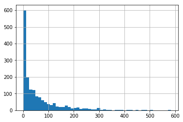

```python
Movie_Stats['Count_of_ratings'].hist(bins=50)
```

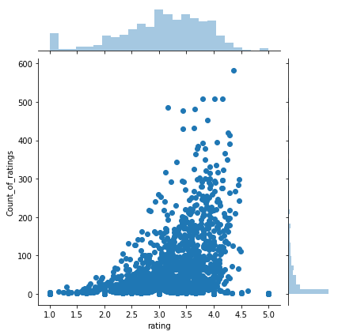

```python
sns.jointplot(x='rating', y='Count_of_ratings', data=Movie_Stats)
```

- The graph shows that, in general, movies with higher average ratings actually have more number of ratings, compared with movies that have lower average ratings.

### Finding Similarities Between Movies

- We will use the correlation between the ratings of a movie as the similarity metric.
- To see the corrilation we will create Pivot table between user_id ,movies, ratings

```python
User_movie_Rating = Movie_Rating.pivot_table(index='user_id', columns='movie_title', values='rating')
User_movie_Rating.head()
```

| movie_title user_id | 'Til There Was You (1997) | 1-900 (1994) | 101 Dalmatians (1996) | 12 Angry Men (1957) | 187 (1997) | 2 Days in the Valley (1996) | 20,000 Leagues Under the Sea (1954) | 2001: A Space Odyssey (1968) | 3 Ninjas: High Noon At Mega Mountain (1998) | 39 Steps, The (1935) | ... | Yankee Zulu (1994) | Year of the Horse (1997) | You So Crazy (1994) | Young Frankenstein (1974) | Young Guns (1988) | Young Guns II (1990) | Young Poisoner's Handbook, The (1995) | Zeus and Roxanne (1997) | unknown | Á köldum klaka (Cold Fever) (1994) |
| --- | --- | --- | --- | --- | --- | --- | --- | --- | --- | --- | --- | --- | --- | --- | --- | --- | --- | --- | --- | --- | --- |
| 1 | NaN | NaN | 2.0 | 5.0 | NaN | NaN | 3.0 | 4.0 | NaN | NaN | ... | NaN | NaN | NaN | 5.0 | 3.0 | NaN | NaN | NaN | 4.0 | NaN |
| 2 | NaN | NaN | NaN | NaN | NaN | NaN | NaN | NaN | 1.0 | NaN | ... | NaN | NaN | NaN | NaN | NaN | NaN | NaN | NaN | NaN | NaN |
| 3 | NaN | NaN | NaN | NaN | 2.0 | NaN | NaN | NaN | NaN | NaN | ... | NaN | NaN | NaN | NaN | NaN | NaN | NaN | NaN | NaN | NaN |
| 4 | NaN | NaN | NaN | NaN | NaN | NaN | NaN | NaN | NaN | NaN | ... | NaN | NaN | NaN | NaN | NaN | NaN | NaN | NaN | NaN | NaN |
| 5 | NaN | NaN | 2.0 | NaN | NaN | NaN | NaN | 4.0 | NaN | NaN | ... | NaN | NaN | NaN | 4.0 | NaN | NaN | NaN | NaN | 4.0 | NaN |

5 rows × 1664 columns

```python
##We can achieve this by computing the correlation between these two movies ratings and the ratings of the rest of the movies in the dataset.
##The first step is to create a dataframe with the ratings of these movies

# Example pick up one movie related rating
User_movie_Rating['Air Force One (1997)']
```

```
user_id
1      NaN
2      4.0
3      2.0
4      5.0
5      NaN
6      NaN
7      4.0
8      NaN
9      NaN
10     NaN
11     3.0
12     4.0
13     1.0
14     NaN
```

[output cut: 48 more lines]

## Correlation Similarity

- We can find the correlation between the user ratings for the **given movie** and all the other movies using corrwith() function as shown below:

```python
Similarity = User_movie_Rating.corrwith(User_movie_Rating['Air Force One (1997)'])
Similarity.head()
```

```
movie_title
'Til There Was You (1997)    0.867722
1-900 (1994)                      NaN
101 Dalmatians (1996)        0.221943
12 Angry Men (1957)          0.228031
187 (1997)                   0.294232
dtype: float64
```

```python
corr_similar = pd.DataFrame(Similarity, columns=['Correlation'])
corr_similar.sort_values(['Correlation'], ascending= False).head(10)
```

| movie_title | Correlation |
| --- | --- |
| Love and Death on Long Island (1997) | 1.0 |
| Losing Chase (1996) | 1.0 |
| Phat Beach (1996) | 1.0 |
| My Crazy Life (Mi vida loca) (1993) | 1.0 |
| Tetsuo II: Body Hammer (1992) | 1.0 |
| Jack and Sarah (1995) | 1.0 |
| Vermin (1998) | 1.0 |
| Faster Pussycat! Kill! Kill! (1965) | 1.0 |
| For Ever Mozart (1996) | 1.0 |
| Men of Means (1998) | 1.0 |

#### We will add the count of rating also to see why many movies are exactly correlating for the single movie

```python
corr_similar_num_of_rating = corr_similar.join(Movie_Stats['Count_of_ratings'])
corr_similar_num_of_rating.sort_values(['Correlation'], ascending= False).head(10)
```

| movie_title | Correlation | Count_of_ratings |
| --- | --- | --- |
| Love and Death on Long Island (1997) | 1.0 | 2 |
| Losing Chase (1996) | 1.0 | 8 |
| Phat Beach (1996) | 1.0 | 5 |
| My Crazy Life (Mi vida loca) (1993) | 1.0 | 11 |
| Tetsuo II: Body Hammer (1992) | 1.0 | 6 |
| Jack and Sarah (1995) | 1.0 | 7 |
| Vermin (1998) | 1.0 | 2 |
| Faster Pussycat! Kill! Kill! (1965) | 1.0 | 7 |
| For Ever Mozart (1996) | 1.0 | 3 |
| Men of Means (1998) | 1.0 | 2 |

- We can able to see that a movie cannot be declared similar to the another movie based on just 2 or 3 ratings.
- This is why we need to filter movies correlated to given movie that have more than 30/50 ratings

```python
corr_similar_num_of_rating[corr_similar_num_of_rating ['Count_of_ratings']>50].sort_values('Correlation', ascending=False).head()
```

| movie_title | Correlation | Count_of_ratings |
| --- | --- | --- |
| Air Force One (1997) | 1.000000 | 431 |
| Black Sheep (1996) | 0.766259 | 55 |
| Copycat (1995) | 0.711744 | 86 |
| Tales from the Crypt Presents: Bordello of Blood (1996) | 0.639372 | 55 |
| Addicted to Love (1997) | 0.576379 | 54 |

**Creation the user defined function to get the similar movies to recommend**

- All the above steps created as one UDF so that we can pass the movie title and get the recomendations

```python
def get_recommendations(title):
    # Get the movie ratings of the movie that matches the title
    Movie_rating = User_movie_Rating[title]

    # Get the  similarity corrilated  scores of all movies with that movie
    sim_scores = User_movie_Rating.corrwith(Movie_rating)

    # Sort the movies based on the similarity scores
    corr_title = pd.DataFrame(sim_scores, columns=['Correlation'])

    # Removing na values
    corr_title.dropna(inplace=True)

    corr_title = corr_title.join(Movie_Stats['Count_of_ratings'])

    # Return the top 10 most similar movies
    return corr_title[corr_title ['Count_of_ratings']>50].sort_values('Correlation', ascending=False).head()
```

```python
# Usage of the above function
get_recommendations('Air Force One (1997)')
```

| movie_title | Correlation | Count_of_ratings |
| --- | --- | --- |
| Air Force One (1997) | 1.000000 | 431 |
| Black Sheep (1996) | 0.766259 | 55 |
| Copycat (1995) | 0.711744 | 86 |
| Tales from the Crypt Presents: Bordello of Blood (1996) | 0.639372 | 55 |
| Addicted to Love (1997) | 0.576379 | 54 |

```python
get_recommendations('Star Wars (1977)')
```

| movie_title | Correlation | Count_of_ratings |
| --- | --- | --- |
| Star Wars (1977) | 1.000000 | 583 |
| Empire Strikes Back, The (1980) | 0.747981 | 367 |
| Return of the Jedi (1983) | 0.672556 | 507 |
| Raiders of the Lost Ark (1981) | 0.536117 | 420 |
| Giant (1956) | 0.488093 | 51 |

=======================================================================================

## Cosine Similarties

- Untill now we have seen the correlation wise now we are going to use cosine similariy to find the similar movies
- Filter out required columns from the dataset

```python
Movie_cosine = Movie_Rating[['user_id','movie_id','rating']]
Movie_cosine.head()
```

|  | user_id | movie_id | rating |
| --- | --- | --- | --- |
| 0 | 196 | 242 | 3 |
| 1 | 63 | 242 | 3 |
| 2 | 226 | 242 | 5 |
| 3 | 154 | 242 | 3 |
| 4 | 306 | 242 | 5 |

- Sparse matrix we are going to create using above data
- A sparse matrix in Coordinate format this is also called as triplet format

```python
data = Movie_cosine.rating
col = Movie_cosine.movie_id
row = Movie_cosine.user_id

R = sparse.coo_matrix((data, (row, col))).tocsr()
print ('{0}x{1} user by movie matrix'.format(*R.shape))
```

```
944x1683 user by movie matrix
```

- Keeping data ,col, row we call it as Triplet Format of Matrix
- The individual elements of the matrix can be listed in any order, and if there are multiple items for the same nonzero position, the values provided for those positions are added.
- Using the **cosine similarity** to measure the similarity between a pair of vectors
- With the cosine similarity, we are going to evaluate the similarity between two vectors based on the angle between them. The smaller the angle, the more similar the two vectors are
- If you recall from trigonometry, the range of the cosine function goes from -1 to 1. Some important properties of cosine to recall:
> - Cosine(0°) = 1
> - Cosine(90°) = 0
> - Cosine(180°) = -1
- If we restrict our vectors to non-negative values (as in the case of movie ratings, usually going from a 1-5 scale), then the angle of separation between the two vectors is bound between 0° and 90°

```python
find_similarities = cosine_similarity(R.T) # We are transposing the matrix
print (find_similarities.shape)
```

```
(1683, 1683)
```

```python
def Get_Top5_Similarmovies(model, movie_id, n=5):
    return model[movie_id].argsort()[::-1][:n].tolist()  # Here movie id is index
```

- index is started with 0 and movie id is started with 1

```python
Movie_D.head()
```

|  | movie_id | movie_title | release_date | video_release_date | IMDb_URL | unknown | Action | Adventure | Animation | Childrens | ... | Fantasy | Film-Noir | Horror | Musical | Mystery | Romance | Sci-Fi | Thriller | War | Western |
| --- | --- | --- | --- | --- | --- | --- | --- | --- | --- | --- | --- | --- | --- | --- | --- | --- | --- | --- | --- | --- | --- |
| 0 | 1 | Toy Story (1995) | 1-Jan-95 | NaN | http://us.imdb.com/M/title-exact?Toy%20Story%2... | 0 | 0 | 0 | 1 | 1 | ... | 0 | 0 | 0 | 0 | 0 | 0 | 0 | 0 | 0 | 0 |
| 1 | 2 | GoldenEye (1995) | 1-Jan-95 | NaN | http://us.imdb.com/M/title-exact?GoldenEye%20(... | 0 | 1 | 1 | 0 | 0 | ... | 0 | 0 | 0 | 0 | 0 | 0 | 0 | 1 | 0 | 0 |
| 2 | 3 | Four Rooms (1995) | 1-Jan-95 | NaN | http://us.imdb.com/M/title-exact?Four%20Rooms%... | 0 | 0 | 0 | 0 | 0 | ... | 0 | 0 | 0 | 0 | 0 | 0 | 0 | 1 | 0 | 0 |
| 3 | 4 | Get Shorty (1995) | 1-Jan-95 | NaN | http://us.imdb.com/M/title-exact?Get%20Shorty%... | 0 | 1 | 0 | 0 | 0 | ... | 0 | 0 | 0 | 0 | 0 | 0 | 0 | 0 | 0 | 0 |
| 4 | 5 | Copycat (1995) | 1-Jan-95 | NaN | http://us.imdb.com/M/title-exact?Copycat%20(1995) | 0 | 0 | 0 | 0 | 0 | ... | 0 | 0 | 0 | 0 | 0 | 0 | 0 | 1 | 0 | 0 |

5 rows × 24 columns

```python
Movie_D.iloc[4]
```

```
movie_id                                                               5
movie_title                                               Copycat (1995)
release_date                                                    1-Jan-95
video_release_date                                                   NaN
IMDb_URL               http://us.imdb.com/M/title-exact?Copycat%20(1995)
unknown                                                                0
Action                                                                 0
Adventure                                                              0
Animation                                                              0
Childrens                                                              0
Comedy                                                                 0
Crime                                                                  1
 Documentary                                                           0
Drama                                                                  1
 Fantasy                                                               0
Film-Noir                                                              0
Horror                                                                 0
Musical                                                                0
Mystery                                                                0
 Romance                                                               0
Sci-Fi                                                                 0
Thriller                                                               1
War                                                                    0
Western                                                                0
Name: 4, dtype: object
```

- Here Index 4 means movie id 5

```python
Movie_D.iloc[Get_Top5_Similarmovies(find_similarities, 4)]
```

|  | movie_id | movie_title | release_date | video_release_date | IMDb_URL | unknown | Action | Adventure | Animation | Childrens | ... | Fantasy | Film-Noir | Horror | Musical | Mystery | Romance | Sci-Fi | Thriller | War | Western |
| --- | --- | --- | --- | --- | --- | --- | --- | --- | --- | --- | --- | --- | --- | --- | --- | --- | --- | --- | --- | --- | --- |
| 4 | 5 | Copycat (1995) | 1-Jan-95 | NaN | http://us.imdb.com/M/title-exact?Copycat%20(1995) | 0 | 0 | 0 | 0 | 0 | ... | 0 | 0 | 0 | 0 | 0 | 0 | 0 | 1 | 0 | 0 |
| 56 | 57 | Priest (1994) | 1-Jan-94 | NaN | http://us.imdb.com/M/title-exact?Priest%20(1994) | 0 | 0 | 0 | 0 | 0 | ... | 0 | 0 | 0 | 0 | 0 | 0 | 0 | 0 | 0 | 0 |
| 204 | 205 | Patton (1970) | 1-Jan-70 | NaN | http://us.imdb.com/M/title-exact?Patton%20(1970) | 0 | 0 | 0 | 0 | 0 | ... | 0 | 0 | 0 | 0 | 0 | 0 | 0 | 0 | 1 | 0 |
| 174 | 175 | Brazil (1985) | 1-Jan-85 | NaN | http://us.imdb.com/M/title-exact?Brazil%20(1985) | 0 | 0 | 0 | 0 | 0 | ... | 0 | 0 | 0 | 0 | 0 | 0 | 1 | 0 | 0 | 0 |
| 202 | 203 | Unforgiven (1992) | 1-Jan-92 | NaN | http://us.imdb.com/M/title-exact?Unforgiven%20... | 0 | 0 | 0 | 0 | 0 | ... | 0 | 0 | 0 | 0 | 0 | 0 | 0 | 0 | 0 | 1 |

5 rows × 24 columns

=======================================================================================

## Matrix Factorization

### Singular Value Decomposition (Matrix Factorization)

$$ df\_array = U\Sigma V^T $$

Now using Singular Value Decomposition, we will decompose our dataframe into smaller matrices. This can be done directly with the help of `scipy` using `scipy.sparse.linalg.svds`.

For Matrix factorization, we need normalized values.

```python
df_matrix = User_movie_Rating.fillna(0)
```

```python
normalized_values = df_matrix.values - np.mean(df_matrix.values, axis=1).reshape(-1,1)
normalized_values
```

```
array([[-0.58713942, -0.58713942,  1.41286058, ..., -0.58713942,
         3.41286058, -0.58713942],
       [-0.13581731, -0.13581731, -0.13581731, ..., -0.13581731,
        -0.13581731, -0.13581731],
       [-0.08834135, -0.08834135, -0.08834135, ..., -0.08834135,
        -0.08834135, -0.08834135],
       ...,
       [-0.05348558, -0.05348558, -0.05348558, ..., -0.05348558,
        -0.05348558, -0.05348558],
       [-0.19951923, -0.19951923, -0.19951923, ..., -0.19951923,
        -0.19951923, -0.19951923],
       [-0.34435096, -0.34435096, -0.34435096, ..., -0.34435096,
        -0.34435096, -0.34435096]])
```

```python
U, SIGMA, VT = svds(normalized_values)
U.shape, SIGMA.shape, VT.shape
```

```
((943, 6), (6,), (6, 1664))
```

Since `SIGMA` is not the same shape as `U` or `VT`, we make it into a diagonal matrix.

```python
SIGMA = np.diag(SIGMA)
```

```python
U.shape, SIGMA.shape, VT.shape
```

```
((943, 6), (6, 6), (6, 1664))
```

Now we can see the values of $U, \Sigma, V$. Notice that $\Sigma$ is a diagonal matrix now.

```python
df_matrix
```

| movie_title user_id | 'Til There Was You (1997) | 1-900 (1994) | 101 Dalmatians (1996) | 12 Angry Men (1957) | 187 (1997) | 2 Days in the Valley (1996) | 20,000 Leagues Under the Sea (1954) | 2001: A Space Odyssey (1968) | 3 Ninjas: High Noon At Mega Mountain (1998) | 39 Steps, The (1935) | ... | Yankee Zulu (1994) | Year of the Horse (1997) | You So Crazy (1994) | Young Frankenstein (1974) | Young Guns (1988) | Young Guns II (1990) | Young Poisoner's Handbook, The (1995) | Zeus and Roxanne (1997) | unknown | Á köldum klaka (Cold Fever) (1994) |
| --- | --- | --- | --- | --- | --- | --- | --- | --- | --- | --- | --- | --- | --- | --- | --- | --- | --- | --- | --- | --- | --- |
| 1 | 0.0 | 0.0 | 2.0 | 5.0 | 0.0 | 0.0 | 3.0 | 4.0 | 0.0 | 0.0 | ... | 0.0 | 0.0 | 0.0 | 5.0 | 3.0 | 0.0 | 0.0 | 0.0 | 4.0 | 0.0 |
| 2 | 0.0 | 0.0 | 0.0 | 0.0 | 0.0 | 0.0 | 0.0 | 0.0 | 1.0 | 0.0 | ... | 0.0 | 0.0 | 0.0 | 0.0 | 0.0 | 0.0 | 0.0 | 0.0 | 0.0 | 0.0 |
| 3 | 0.0 | 0.0 | 0.0 | 0.0 | 2.0 | 0.0 | 0.0 | 0.0 | 0.0 | 0.0 | ... | 0.0 | 0.0 | 0.0 | 0.0 | 0.0 | 0.0 | 0.0 | 0.0 | 0.0 | 0.0 |
| 4 | 0.0 | 0.0 | 0.0 | 0.0 | 0.0 | 0.0 | 0.0 | 0.0 | 0.0 | 0.0 | ... | 0.0 | 0.0 | 0.0 | 0.0 | 0.0 | 0.0 | 0.0 | 0.0 | 0.0 | 0.0 |
| 5 | 0.0 | 0.0 | 2.0 | 0.0 | 0.0 | 0.0 | 0.0 | 4.0 | 0.0 | 0.0 | ... | 0.0 | 0.0 | 0.0 | 4.0 | 0.0 | 0.0 | 0.0 | 0.0 | 4.0 | 0.0 |
| 6 | 0.0 | 0.0 | 0.0 | 4.0 | 0.0 | 0.0 | 0.0 | 5.0 | 0.0 | 0.0 | ... | 0.0 | 0.0 | 0.0 | 4.0 | 0.0 | 0.0 | 0.0 | 0.0 | 0.0 | 0.0 |
| 7 | 0.0 | 0.0 | 0.0 | 4.0 | 0.0 | 0.0 | 5.0 | 5.0 | 0.0 | 4.0 | ... | 0.0 | 0.0 | 0.0 | 5.0 | 3.0 | 0.0 | 3.0 | 0.0 | 0.0 | 0.0 |
| 8 | 0.0 | 0.0 | 0.0 | 0.0 | 0.0 | 0.0 | 0.0 | 0.0 | 0.0 | 0.0 | ... | 0.0 | 0.0 | 0.0 | 0.0 | 0.0 | 0.0 | 0.0 | 0.0 | 0.0 | 0.0 |
| 9 | 0.0 | 0.0 | 0.0 | 0.0 | 0.0 | 0.0 | 0.0 | 0.0 | 0.0 | 4.0 | ... | 0.0 | 0.0 | 0.0 | 0.0 | 0.0 | 0.0 | 0.0 | 0.0 | 0.0 | 0.0 |
| 10 | 0.0 | 0.0 | 0.0 | 5.0 | 0.0 | 0.0 | 0.0 | 5.0 | 0.0 | 4.0 | ... | 0.0 | 0.0 | 0.0 | 0.0 | 0.0 | 0.0 | 0.0 | 0.0 | 0.0 | 0.0 |
| 11 | 0.0 | 0.0 | 0.0 | 0.0 | 0.0 | 0.0 | 0.0 | 4.0 | 0.0 | 0.0 | ... | 0.0 | 0.0 | 0.0 | 4.0 | 0.0 | 0.0 | 0.0 | 0.0 | 0.0 | 0.0 |
| 12 | 0.0 | 0.0 | 0.0 | 0.0 | 0.0 | 0.0 | 0.0 | 0.0 | 0.0 | 0.0 | ... | 0.0 | 0.0 | 0.0 | 0.0 | 0.0 | 0.0 | 0.0 | 0.0 | 0.0 | 0.0 |
| 13 | 0.0 | 0.0 | 2.0 | 4.0 | 0.0 | 0.0 | 2.0 | 5.0 | 1.0 | 4.0 | ... | 0.0 | 2.0 | 0.0 | 5.0 | 3.0 | 0.0 | 1.0 | 0.0 | 0.0 | 0.0 |
| 14 | 0.0 | 0.0 | 0.0 | 0.0 | 0.0 | 0.0 | 0.0 | 0.0 | 0.0 | 0.0 | ... | 0.0 | 0.0 | 0.0 | 0.0 | 0.0 | 0.0 | 0.0 | 0.0 | 0.0 | 0.0 |
| 15 | 0.0 | 0.0 | 3.0 | 0.0 | 0.0 | 0.0 | 0.0 | 0.0 | 0.0 | 0.0 | ... | 0.0 | 0.0 | 0.0 | 0.0 | 0.0 | 0.0 | 0.0 | 0.0 | 0.0 | 0.0 |
| 16 | 0.0 | 0.0 | 0.0 | 5.0 | 0.0 | 0.0 | 0.0 | 4.0 | 0.0 | 0.0 | ... | 0.0 | 0.0 | 0.0 | 5.0 | 0.0 | 0.0 | 0.0 | 0.0 | 0.0 | 0.0 |
| 17 | 0.0 | 0.0 | 0.0 | 0.0 | 0.0 | 0.0 | 0.0 | 0.0 | 0.0 | 0.0 | ... | 0.0 | 0.0 | 0.0 | 0.0 | 0.0 | 0.0 | 0.0 | 0.0 | 0.0 | 0.0 |
| 18 | 0.0 | 0.0 | 0.0 | 3.0 | 0.0 | 0.0 | 0.0 | 3.0 | 0.0 | 0.0 | ... | 0.0 | 0.0 | 0.0 | 4.0 | 0.0 | 0.0 | 0.0 | 0.0 | 0.0 | 0.0 |
| 19 | 0.0 | 0.0 | 0.0 | 0.0 | 0.0 | 0.0 | 0.0 | 0.0 | 0.0 | 0.0 | ... | 0.0 | 0.0 | 0.0 | 0.0 | 0.0 | 0.0 | 0.0 | 0.0 | 0.0 | 0.0 |
| 20 | 0.0 | 0.0 | 0.0 | 0.0 | 0.0 | 0.0 | 0.0 | 0.0 | 0.0 | 0.0 | ... | 0.0 | 0.0 | 0.0 | 2.0 | 0.0 | 0.0 | 0.0 | 0.0 | 0.0 | 0.0 |
| 21 | 0.0 | 0.0 | 0.0 | 0.0 | 4.0 | 0.0 | 0.0 | 0.0 | 0.0 | 0.0 | ... | 0.0 | 0.0 | 0.0 | 0.0 | 0.0 | 0.0 | 2.0 | 0.0 | 0.0 | 0.0 |
| 22 | 0.0 | 0.0 | 0.0 | 0.0 | 0.0 | 0.0 | 0.0 | 0.0 | 0.0 | 0.0 | ... | 0.0 | 0.0 | 0.0 | 5.0 | 0.0 | 0.0 | 0.0 | 0.0 | 0.0 | 0.0 |
| 23 | 0.0 | 0.0 | 0.0 | 0.0 | 0.0 | 0.0 | 0.0 | 0.0 | 0.0 | 0.0 | ... | 0.0 | 0.0 | 0.0 | 0.0 | 0.0 | 0.0 | 0.0 | 0.0 | 0.0 | 0.0 |
| 24 | 0.0 | 0.0 | 0.0 | 5.0 | 0.0 | 0.0 | 0.0 | 0.0 | 0.0 | 0.0 | ... | 0.0 | 0.0 | 0.0 | 0.0 | 0.0 | 0.0 | 0.0 | 0.0 | 0.0 | 0.0 |
| 25 | 0.0 | 0.0 | 0.0 | 0.0 | 0.0 | 0.0 | 4.0 | 3.0 | 0.0 | 5.0 | ... | 0.0 | 0.0 | 0.0 | 4.0 | 0.0 | 0.0 | 0.0 | 0.0 | 0.0 | 0.0 |
| 26 | 0.0 | 0.0 | 0.0 | 0.0 | 0.0 | 3.0 | 0.0 | 0.0 | 0.0 | 0.0 | ... | 0.0 | 0.0 | 0.0 | 0.0 | 0.0 | 0.0 | 0.0 | 0.0 | 0.0 | 0.0 |
| 27 | 0.0 | 0.0 | 0.0 | 0.0 | 0.0 | 0.0 | 0.0 | 0.0 | 0.0 | 0.0 | ... | 0.0 | 0.0 | 0.0 | 0.0 | 0.0 | 0.0 | 0.0 | 0.0 | 0.0 | 0.0 |
| 28 | 0.0 | 0.0 | 0.0 | 0.0 | 0.0 | 0.0 | 0.0 | 0.0 | 0.0 | 0.0 | ... | 0.0 | 0.0 | 0.0 | 0.0 | 0.0 | 0.0 | 0.0 | 0.0 | 0.0 | 0.0 |
| 29 | 0.0 | 0.0 | 0.0 | 0.0 | 0.0 | 0.0 | 0.0 | 0.0 | 0.0 | 0.0 | ... | 0.0 | 0.0 | 0.0 | 0.0 | 0.0 | 0.0 | 0.0 | 0.0 | 0.0 | 0.0 |
| 30 | 0.0 | 0.0 | 0.0 | 0.0 | 0.0 | 0.0 | 0.0 | 5.0 | 0.0 | 0.0 | ... | 0.0 | 0.0 | 0.0 | 0.0 | 0.0 | 0.0 | 0.0 | 0.0 | 0.0 | 0.0 |
| ... | ... | ... | ... | ... | ... | ... | ... | ... | ... | ... | ... | ... | ... | ... | ... | ... | ... | ... | ... | ... | ... |
| 914 | 0.0 | 0.0 | 0.0 | 0.0 | 0.0 | 0.0 | 0.0 | 0.0 | 0.0 | 0.0 | ... | 0.0 | 0.0 | 0.0 | 0.0 | 0.0 | 0.0 | 0.0 | 0.0 | 0.0 | 0.0 |
| 915 | 0.0 | 0.0 | 0.0 | 0.0 | 0.0 | 0.0 | 0.0 | 0.0 | 0.0 | 0.0 | ... | 0.0 | 0.0 | 0.0 | 0.0 | 0.0 | 0.0 | 0.0 | 0.0 | 0.0 | 0.0 |
| 916 | 0.0 | 0.0 | 0.0 | 0.0 | 0.0 | 4.0 | 0.0 | 4.0 | 0.0 | 0.0 | ... | 0.0 | 0.0 | 0.0 | 0.0 | 3.0 | 0.0 | 0.0 | 0.0 | 0.0 | 0.0 |
| 917 | 0.0 | 0.0 | 0.0 | 0.0 | 0.0 | 0.0 | 0.0 | 0.0 | 0.0 | 0.0 | ... | 0.0 | 0.0 | 0.0 | 0.0 | 0.0 | 0.0 | 0.0 | 0.0 | 0.0 | 0.0 |
| 918 | 0.0 | 0.0 | 0.0 | 0.0 | 0.0 | 0.0 | 0.0 | 1.0 | 0.0 | 0.0 | ... | 0.0 | 0.0 | 0.0 | 3.0 | 0.0 | 0.0 | 0.0 | 0.0 | 0.0 | 0.0 |
| 919 | 0.0 | 0.0 | 0.0 | 0.0 | 0.0 | 0.0 | 0.0 | 0.0 | 0.0 | 0.0 | ... | 0.0 | 0.0 | 0.0 | 0.0 | 0.0 | 0.0 | 0.0 | 0.0 | 0.0 | 0.0 |
| 920 | 0.0 | 0.0 | 0.0 | 0.0 | 0.0 | 0.0 | 0.0 | 0.0 | 0.0 | 0.0 | ... | 0.0 | 0.0 | 0.0 | 0.0 | 0.0 | 0.0 | 0.0 | 0.0 | 0.0 | 0.0 |
| 921 | 0.0 | 0.0 | 0.0 | 0.0 | 0.0 | 0.0 | 0.0 | 0.0 | 0.0 | 0.0 | ... | 0.0 | 0.0 | 0.0 | 0.0 | 0.0 | 0.0 | 0.0 | 0.0 | 0.0 | 0.0 |
| 922 | 0.0 | 0.0 | 0.0 | 0.0 | 0.0 | 0.0 | 0.0 | 2.0 | 0.0 | 0.0 | ... | 0.0 | 0.0 | 0.0 | 0.0 | 0.0 | 0.0 | 0.0 | 0.0 | 0.0 | 0.0 |
| 923 | 0.0 | 0.0 | 0.0 | 0.0 | 0.0 | 4.0 | 0.0 | 0.0 | 0.0 | 0.0 | ... | 0.0 | 0.0 | 0.0 | 0.0 | 0.0 | 0.0 | 0.0 | 0.0 | 0.0 | 0.0 |
| 924 | 0.0 | 0.0 | 0.0 | 5.0 | 0.0 | 3.0 | 0.0 | 0.0 | 0.0 | 0.0 | ... | 0.0 | 0.0 | 0.0 | 0.0 | 0.0 | 0.0 | 0.0 | 0.0 | 0.0 | 0.0 |
| 925 | 0.0 | 0.0 | 0.0 | 0.0 | 0.0 | 0.0 | 0.0 | 0.0 | 0.0 | 0.0 | ... | 0.0 | 0.0 | 0.0 | 0.0 | 0.0 | 0.0 | 0.0 | 0.0 | 0.0 | 0.0 |
| 926 | 0.0 | 0.0 | 0.0 | 0.0 | 0.0 | 0.0 | 0.0 | 0.0 | 0.0 | 0.0 | ... | 0.0 | 0.0 | 0.0 | 0.0 | 0.0 | 0.0 | 0.0 | 0.0 | 0.0 | 0.0 |
| 927 | 0.0 | 0.0 | 0.0 | 0.0 | 0.0 | 0.0 | 0.0 | 0.0 | 0.0 | 0.0 | ... | 0.0 | 0.0 | 0.0 | 0.0 | 0.0 | 0.0 | 0.0 | 0.0 | 0.0 | 0.0 |
| 928 | 0.0 | 0.0 | 0.0 | 0.0 | 0.0 | 0.0 | 0.0 | 4.0 | 0.0 | 0.0 | ... | 0.0 | 0.0 | 0.0 | 0.0 | 0.0 | 0.0 | 0.0 | 0.0 | 0.0 | 0.0 |
| 929 | 0.0 | 0.0 | 0.0 | 0.0 | 0.0 | 0.0 | 0.0 | 5.0 | 0.0 | 0.0 | ... | 0.0 | 0.0 | 0.0 | 0.0 | 0.0 | 0.0 | 0.0 | 0.0 | 0.0 | 0.0 |
| 930 | 0.0 | 0.0 | 0.0 | 0.0 | 0.0 | 0.0 | 0.0 | 0.0 | 0.0 | 0.0 | ... | 0.0 | 0.0 | 0.0 | 0.0 | 0.0 | 0.0 | 0.0 | 0.0 | 0.0 | 0.0 |
| 931 | 0.0 | 0.0 | 0.0 | 0.0 | 0.0 | 0.0 | 0.0 | 0.0 | 0.0 | 0.0 | ... | 0.0 | 0.0 | 0.0 | 0.0 | 0.0 | 0.0 | 0.0 | 0.0 | 0.0 | 0.0 |
| 932 | 0.0 | 0.0 | 2.0 | 5.0 | 0.0 | 0.0 | 4.0 | 5.0 | 0.0 | 5.0 | ... | 0.0 | 0.0 | 0.0 | 5.0 | 0.0 | 0.0 | 0.0 | 0.0 | 0.0 | 0.0 |
| 933 | 0.0 | 0.0 | 0.0 | 0.0 | 0.0 | 0.0 | 0.0 | 4.0 | 0.0 | 0.0 | ... | 0.0 | 0.0 | 0.0 | 0.0 | 1.0 | 1.0 | 0.0 | 0.0 | 0.0 | 0.0 |
| 934 | 0.0 | 0.0 | 2.0 | 0.0 | 0.0 | 0.0 | 0.0 | 4.0 | 0.0 | 0.0 | ... | 0.0 | 0.0 | 0.0 | 5.0 | 0.0 | 0.0 | 0.0 | 0.0 | 0.0 | 0.0 |
| 935 | 0.0 | 0.0 | 0.0 | 0.0 | 0.0 | 0.0 | 0.0 | 0.0 | 0.0 | 0.0 | ... | 0.0 | 0.0 | 0.0 | 0.0 | 0.0 | 0.0 | 0.0 | 0.0 | 0.0 | 0.0 |
| 936 | 0.0 | 0.0 | 0.0 | 0.0 | 0.0 | 4.0 | 0.0 | 0.0 | 0.0 | 0.0 | ... | 0.0 | 0.0 | 0.0 | 0.0 | 0.0 | 0.0 | 5.0 | 0.0 | 0.0 | 0.0 |
| 937 | 0.0 | 0.0 | 2.0 | 0.0 | 0.0 | 0.0 | 0.0 | 0.0 | 0.0 | 0.0 | ... | 0.0 | 0.0 | 0.0 | 0.0 | 0.0 | 0.0 | 0.0 | 0.0 | 0.0 | 0.0 |
| 938 | 0.0 | 0.0 | 4.0 | 0.0 | 0.0 | 0.0 | 0.0 | 0.0 | 0.0 | 0.0 | ... | 0.0 | 0.0 | 0.0 | 0.0 | 0.0 | 0.0 | 0.0 | 0.0 | 0.0 | 0.0 |
| 939 | 0.0 | 0.0 | 0.0 | 0.0 | 0.0 | 0.0 | 0.0 | 0.0 | 0.0 | 0.0 | ... | 0.0 | 0.0 | 0.0 | 0.0 | 0.0 | 0.0 | 0.0 | 0.0 | 0.0 | 0.0 |
| 940 | 0.0 | 0.0 | 0.0 | 0.0 | 0.0 | 0.0 | 0.0 | 0.0 | 0.0 | 0.0 | ... | 0.0 | 0.0 | 0.0 | 0.0 | 0.0 | 0.0 | 0.0 | 0.0 | 0.0 | 0.0 |
| 941 | 0.0 | 0.0 | 0.0 | 0.0 | 0.0 | 0.0 | 0.0 | 0.0 | 0.0 | 0.0 | ... | 0.0 | 0.0 | 0.0 | 0.0 | 0.0 | 0.0 | 0.0 | 0.0 | 0.0 | 0.0 |
| 942 | 0.0 | 0.0 | 0.0 | 0.0 | 0.0 | 0.0 | 0.0 | 3.0 | 0.0 | 3.0 | ... | 0.0 | 0.0 | 0.0 | 0.0 | 0.0 | 0.0 | 0.0 | 0.0 | 0.0 | 0.0 |
| 943 | 0.0 | 0.0 | 0.0 | 0.0 | 0.0 | 2.0 | 0.0 | 0.0 | 0.0 | 0.0 | ... | 0.0 | 0.0 | 0.0 | 0.0 | 4.0 | 3.0 | 0.0 | 0.0 | 0.0 | 0.0 |

943 rows × 1664 columns

```python
reconstructed_df = np.dot(np.dot(U, SIGMA), VT) + np.mean(df_matrix.values, axis=1).reshape(-1, 1)
predictions_df = pd.DataFrame(reconstructed_df, columns = df_matrix.columns)
predictions_df
```

| movie_title | 'Til There Was You (1997) | 1-900 (1994) | 101 Dalmatians (1996) | 12 Angry Men (1957) | 187 (1997) | 2 Days in the Valley (1996) | 20,000 Leagues Under the Sea (1954) | 2001: A Space Odyssey (1968) | 3 Ninjas: High Noon At Mega Mountain (1998) | 39 Steps, The (1935) | ... | Yankee Zulu (1994) | Year of the Horse (1997) | You So Crazy (1994) | Young Frankenstein (1974) | Young Guns (1988) | Young Guns II (1990) | Young Poisoner's Handbook, The (1995) | Zeus and Roxanne (1997) | unknown | Á köldum klaka (Cold Fever) (1994) |
| --- | --- | --- | --- | --- | --- | --- | --- | --- | --- | --- | --- | --- | --- | --- | --- | --- | --- | --- | --- | --- | --- |
| 0 | -0.008376 | 0.040828 | 0.255097 | 1.368637 | 0.086250 | 1.412191 | 0.490817 | 3.157662 | -0.027797 | 0.324986 | ... | -0.028977 | -0.003432 | -0.017040 | 2.536312 | 1.662737 | 0.666667 | 0.670269 | -0.049776 | 0.129188 | -0.005724 |
| 1 | 0.038789 | -0.044555 | 0.326952 | 0.133404 | 0.342076 | 0.530822 | -0.318530 | -0.024044 | -0.020123 | -0.082302 | ... | -0.040017 | 0.011209 | -0.040759 | -0.255696 | -0.368808 | -0.202552 | 0.224910 | -0.004341 | -0.026679 | -0.021383 |
| 2 | 0.051939 | 0.008640 | -0.154229 | 0.001675 | 0.373526 | 0.077553 | -0.027438 | 0.008863 | 0.028092 | -0.041838 | ... | 0.014913 | 0.061333 | 0.014861 | -0.246739 | 0.130785 | 0.059758 | 0.094154 | -0.002092 | 0.058520 | 0.020152 |
| 3 | 0.016714 | -0.009719 | -0.007841 | 0.027480 | 0.235820 | 0.077210 | 0.039097 | 0.119632 | 0.002121 | 0.006895 | ... | -0.006565 | 0.021345 | -0.004972 | -0.104974 | 0.088231 | 0.028096 | 0.038567 | -0.010205 | 0.026276 | -0.005262 |
| 4 | 0.039749 | 0.064445 | 0.482236 | 0.667350 | -0.026506 | 0.372200 | 0.780897 | 1.681404 | 0.040625 | 0.334868 | ... | 0.051029 | 0.034790 | 0.060711 | 1.524330 | 1.131505 | 0.499319 | 0.068121 | 0.048664 | 0.122230 | 0.039145 |
| 5 | -0.023912 | 0.062152 | 0.128513 | 2.703320 | 0.013552 | 0.331147 | 0.816331 | 4.292271 | 0.013495 | 1.800758 | ... | -0.012645 | 0.052678 | -0.005738 | 2.683918 | -0.455536 | -0.391933 | 0.368426 | 0.012802 | -0.055008 | 0.012775 |
| 6 | 0.250950 | 0.322421 | 0.703982 | 3.608192 | 0.209865 | 0.182696 | 2.468875 | 6.333909 | 0.279539 | 2.404307 | ... | 0.274461 | 0.327062 | 0.290763 | 4.853118 | 1.677596 | 0.666046 | 0.239397 | 0.251226 | 0.320476 | 0.263086 |
| 7 | -0.086035 | -0.017031 | -0.015568 | 0.420149 | 0.067936 | 0.177707 | 0.542724 | 1.479968 | -0.048712 | 0.336866 | ... | -0.049041 | -0.048124 | -0.037303 | 0.822997 | 0.700829 | 0.260260 | 0.031982 | -0.063608 | 0.042233 | -0.059207 |
| 8 | 0.002741 | 0.005160 | 0.073705 | 0.228515 | 0.063128 | 0.096191 | 0.060185 | 0.381519 | 0.003139 | 0.167317 | ... | -0.001956 | 0.008569 | -0.000422 | 0.159217 | -0.091958 | -0.058400 | 0.054529 | 0.006922 | 0.000296 | 0.000781 |
| 9 | -0.027215 | 0.076606 | -0.192344 | 2.496347 | 0.055766 | 0.401753 | 0.770103 | 4.213219 | 0.016694 | 1.571815 | ... | -0.005529 | 0.060076 | 0.001638 | 2.675330 | 0.055610 | -0.138218 | 0.448404 | -0.016026 | 0.001819 | 0.020638 |
| 10 | 0.097023 | -0.051133 | 0.595677 | 0.954593 | 0.176880 | 0.403541 | 0.418993 | 1.286052 | -0.014061 | 0.102640 | ... | -0.019397 | 0.038372 | -0.022029 | 1.539665 | 0.828427 | 0.284150 | 0.081516 | -0.016322 | 0.004642 | -0.007741 |
| 11 | -0.046789 | -0.128427 | 0.467968 | 0.580632 | -0.038922 | 0.032164 | 0.407070 | 0.929140 | -0.104978 | 0.133039 | ... | -0.105466 | -0.082203 | -0.104185 | 1.018674 | 0.416015 | 0.071441 | -0.164364 | -0.090979 | -0.097600 | -0.107919 |
| 12 | 0.542187 | 0.472302 | 0.780833 | 3.073176 | 0.947582 | 0.811686 | 1.863979 | 4.944522 | 0.479973 | 1.807983 | ... | 0.455328 | 0.576018 | 0.463655 | 3.747752 | 1.733050 | 0.832912 | 0.679206 | 0.426053 | 0.543351 | 0.466967 |
| 13 | -0.074713 | -0.016882 | 0.102079 | 1.040372 | -0.016744 | 0.728754 | 0.064684 | 1.965499 | -0.062493 | 0.515921 | ... | -0.074370 | -0.051661 | -0.068212 | 1.196683 | -0.010948 | -0.103402 | 0.396125 | -0.054569 | -0.043114 | -0.052186 |
| 14 | 0.111726 | 0.022945 | 0.857142 | 0.064151 | 0.286954 | 0.597562 | -0.126284 | -0.173844 | 0.051954 | -0.009791 | ... | 0.038831 | 0.059800 | 0.040448 | -0.226107 | -0.420843 | -0.174069 | 0.165499 | 0.109432 | 0.028741 | 0.046811 |
| 15 | -0.104965 | -0.099214 | 0.365969 | 1.468696 | -0.034259 | 0.439508 | 0.846651 | 2.980097 | -0.124693 | 0.665035 | ... | -0.128272 | -0.095877 | -0.117879 | 2.324049 | 0.997405 | 0.271507 | 0.085123 | -0.129832 | -0.051148 | -0.125616 |
| 16 | -0.015834 | -0.013084 | 0.201599 | 0.003322 | 0.033049 | 0.449178 | -0.225402 | 0.067037 | -0.023633 | -0.067193 | ... | -0.028533 | -0.027514 | -0.026568 | -0.065900 | -0.176283 | -0.088076 | 0.185110 | -0.002370 | -0.016343 | -0.018748 |
| 17 | 0.122081 | 0.023533 | 0.705781 | 3.250678 | -0.077596 | 0.273220 | 0.987888 | 4.305620 | 0.034336 | 1.642309 | ... | 0.014756 | 0.109504 | 0.009043 | 3.736488 | -0.022893 | -0.234001 | 0.240208 | 0.044685 | -0.096805 | 0.048805 |
| 18 | -0.008300 | -0.033581 | -0.009696 | 0.121606 | 0.082601 | 0.032292 | 0.038830 | 0.205231 | -0.025666 | -0.001855 | ... | -0.029628 | -0.010624 | -0.029685 | 0.144448 | 0.123464 | 0.025584 | 0.003733 | -0.034934 | -0.014163 | -0.027098 |
| 19 | -0.010661 | -0.039822 | 0.616352 | 0.275221 | -0.042704 | 0.079857 | 0.393396 | 0.563296 | -0.029974 | 0.190833 | ... | -0.027545 | -0.036523 | -0.022521 | 0.538387 | 0.140444 | 0.021040 | -0.138547 | 0.008960 | -0.027304 | -0.038317 |
| 20 | 0.141684 | 0.202515 | 0.135573 | 0.072697 | 0.412811 | 0.853296 | 0.030487 | 0.627671 | 0.168314 | 0.127075 | ... | 0.159328 | 0.165690 | 0.168298 | 0.012101 | 0.375481 | 0.277928 | 0.516531 | 0.165014 | 0.252373 | 0.166784 |
| 21 | -0.042585 | 0.010468 | 0.276301 | 0.643147 | 0.008803 | 0.283648 | 0.857777 | 1.942601 | -0.021503 | 0.380696 | ... | -0.013845 | -0.023860 | -0.000515 | 1.484587 | 1.223596 | 0.501647 | 0.014733 | -0.028389 | 0.091164 | -0.029675 |
| 22 | -0.055730 | -0.046883 | 0.323633 | 1.350480 | -0.050745 | 0.423397 | 0.652776 | 2.544780 | -0.071439 | 0.631901 | ... | -0.075094 | -0.048665 | -0.067979 | 2.010842 | 0.689735 | 0.176133 | 0.141467 | -0.071678 | -0.030713 | -0.068181 |
| 23 | -0.082114 | -0.105817 | 0.189748 | 0.465553 | 0.041539 | 0.679860 | -0.086494 | 1.004321 | -0.119975 | -0.043989 | ... | -0.127697 | -0.099455 | -0.124392 | 0.761847 | 0.336968 | 0.051650 | 0.248782 | -0.116077 | -0.071555 | -0.109943 |
| 24 | -0.045026 | -0.015891 | 0.521365 | 1.040525 | -0.077658 | 0.138868 | 0.635745 | 1.898875 | -0.031997 | 0.762486 | ... | -0.036175 | -0.033397 | -0.027811 | 1.289666 | -0.007011 | -0.098168 | -0.024539 | 0.001826 | -0.042549 | -0.040897 |
| 25 | 0.035835 | 0.003988 | 0.708212 | -0.088827 | 0.317324 | 1.014457 | -0.305459 | 0.050947 | 0.001477 | -0.136442 | ... | -0.013670 | 0.001258 | -0.006610 | -0.323308 | -0.254800 | -0.106895 | 0.367411 | 0.053990 | 0.037486 | -0.000092 |
| 26 | 0.000665 | 0.011863 | 0.164441 | -0.013896 | 0.050139 | 0.327252 | -0.103554 | 0.087537 | 0.002047 | -0.012996 | ... | -0.001133 | -0.003559 | 0.001523 | -0.062138 | -0.086317 | -0.032128 | 0.137305 | 0.017875 | 0.014144 | 0.003358 |
| 27 | -0.069581 | -0.015802 | 0.012111 | 0.470156 | 0.095311 | 0.337564 | 0.430339 | 1.477672 | -0.046570 | 0.277912 | ... | -0.048951 | -0.040270 | -0.038587 | 0.866995 | 0.694100 | 0.256351 | 0.121534 | -0.061205 | 0.042681 | -0.052333 |
| 28 | 0.006645 | -0.015658 | -0.177182 | 0.182681 | 0.254314 | 0.065605 | 0.002487 | 0.329586 | -0.006816 | 0.070648 | ... | -0.018705 | 0.021876 | -0.018259 | 0.004370 | 0.064649 | 0.000171 | 0.085746 | -0.033010 | 0.014313 | -0.012056 |
| 29 | 0.004140 | -0.042484 | 0.178683 | 0.211929 | 0.204017 | 0.079043 | 0.171752 | 0.398586 | -0.024523 | 0.082762 | ... | -0.032995 | -0.002163 | -0.030771 | 0.192156 | 0.141680 | 0.020105 | -0.019320 | -0.026834 | -0.005112 | -0.033266 |
| ... | ... | ... | ... | ... | ... | ... | ... | ... | ... | ... | ... | ... | ... | ... | ... | ... | ... | ... | ... | ... | ... |
| 913 | 0.031811 | -0.022926 | 0.136419 | 0.080291 | 0.027253 | -0.026809 | 0.038569 | -0.063264 | -0.003463 | -0.074762 | ... | -0.003473 | 0.009387 | -0.006294 | 0.168896 | 0.122438 | 0.041348 | -0.048803 | -0.003310 | -0.012619 | -0.002088 |
| 914 | 0.018918 | -0.033893 | -0.158414 | 0.005494 | 0.290959 | 0.024042 | -0.086458 | -0.061277 | -0.011827 | -0.087531 | ... | -0.023928 | 0.021516 | -0.025421 | -0.218087 | 0.055749 | 0.001570 | 0.045829 | -0.038765 | 0.006153 | -0.017239 |
| 915 | 0.036912 | 0.052900 | 0.180532 | 1.318642 | 0.072977 | 1.476162 | 0.446986 | 2.994405 | -0.009841 | 0.087248 | ... | -0.005577 | 0.023716 | 0.002609 | 2.749589 | 2.101366 | 0.883066 | 0.716446 | -0.049290 | 0.164453 | 0.021619 |
| 916 | 0.019040 | -0.002995 | 0.403248 | -0.037415 | 0.042336 | 0.487852 | -0.217123 | -0.105620 | -0.004012 | -0.110736 | ... | -0.007888 | -0.009643 | -0.006633 | -0.093403 | -0.201083 | -0.085945 | 0.166955 | 0.030417 | -0.006686 | 0.000721 |
| 917 | 0.084979 | 0.038618 | 0.209867 | 0.997716 | -0.018801 | 0.036776 | 0.259804 | 1.130459 | 0.048914 | 0.480626 | ... | 0.043626 | 0.074602 | 0.038995 | 1.111160 | -0.050930 | -0.068918 | 0.085122 | 0.049922 | -0.009188 | 0.056127 |
| 918 | 0.154805 | -0.011770 | 0.845683 | 0.399854 | 0.636130 | 1.255848 | -0.229593 | 0.479460 | 0.026473 | -0.235319 | ... | 0.001059 | 0.083322 | 0.002190 | 0.329353 | 0.293552 | 0.103767 | 0.496663 | 0.049474 | 0.077056 | 0.029932 |
| 919 | 0.018338 | -0.037088 | -0.160752 | -0.020031 | 0.323223 | 0.023093 | -0.076423 | -0.073973 | -0.013279 | -0.097308 | ... | -0.026259 | 0.021846 | -0.027312 | -0.259931 | 0.076572 | 0.010251 | 0.040710 | -0.041810 | 0.009993 | -0.020292 |
| 920 | 0.065181 | -0.044980 | 1.186382 | 0.418468 | 0.075097 | 0.202499 | 0.603543 | 0.627691 | -0.005155 | 0.195460 | ... | -0.004256 | -0.001459 | 0.000990 | 0.795263 | 0.276947 | 0.076667 | -0.202577 | 0.060159 | -0.008982 | -0.018813 |
| 921 | -0.015944 | -0.079319 | 0.708267 | 0.460472 | -0.012078 | 0.349088 | 0.677802 | 1.227390 | -0.070969 | 0.004067 | ... | -0.061999 | -0.061412 | -0.054485 | 1.387785 | 1.195875 | 0.463394 | -0.097072 | -0.052762 | 0.013064 | -0.074060 |
| 922 | 0.050300 | 0.071587 | 0.774007 | -0.217118 | 0.157644 | 1.066803 | -0.191517 | 0.062536 | 0.046604 | -0.141118 | ... | 0.042993 | 0.018690 | 0.052695 | -0.190422 | -0.024127 | 0.049058 | 0.382697 | 0.110090 | 0.099243 | 0.048731 |
| 923 | -0.051395 | -0.044292 | 0.427188 | 0.851875 | 0.006799 | 0.297438 | 0.398427 | 1.578331 | -0.055909 | 0.527631 | ... | -0.063591 | -0.047659 | -0.056745 | 1.030677 | 0.022292 | -0.086963 | 0.058704 | -0.031027 | -0.051298 | -0.061118 |
| 924 | 0.016848 | 0.018800 | -0.110136 | -0.017805 | 0.151538 | 0.135441 | 0.010635 | 0.137035 | 0.016053 | -0.042015 | ... | 0.012500 | 0.026181 | 0.014124 | -0.013153 | 0.240994 | 0.118277 | 0.095585 | -0.001201 | 0.051615 | 0.014452 |
| 925 | 0.003486 | -0.053934 | -0.073237 | 0.023112 | 0.259358 | 0.041645 | -0.097045 | -0.053615 | -0.030651 | -0.080457 | ... | -0.042904 | 0.000654 | -0.044184 | -0.203088 | -0.025425 | -0.047957 | 0.025638 | -0.048726 | -0.019712 | -0.036148 |
| 926 | 0.100971 | -0.025085 | 1.295267 | 0.030267 | 0.065713 | 0.476023 | 0.566563 | 0.233885 | 0.011580 | -0.229080 | ... | 0.022931 | 0.007165 | 0.028860 | 0.816579 | 0.944490 | 0.426468 | -0.137544 | 0.074628 | 0.066154 | 0.005406 |
| 927 | -0.016999 | -0.009448 | -0.054575 | 0.360105 | 0.095194 | 0.139659 | 0.084396 | 0.682693 | -0.016348 | 0.199137 | ... | -0.023571 | -0.002026 | -0.021532 | 0.342513 | 0.050628 | -0.015383 | 0.098761 | -0.026634 | -0.002985 | -0.017702 |
| 928 | -0.099161 | -0.007808 | -0.083862 | 0.891316 | -0.072851 | 0.063343 | 0.450744 | 1.864175 | -0.047142 | 0.706974 | ... | -0.052619 | -0.047082 | -0.044348 | 1.030834 | 0.035465 | -0.071268 | 0.069775 | -0.051738 | -0.031758 | -0.052627 |
| 929 | 0.019384 | -0.011282 | 0.466928 | 0.209209 | 0.049255 | 0.422530 | -0.052789 | 0.269040 | -0.008312 | 0.048449 | ... | -0.013579 | -0.007485 | -0.011849 | 0.200353 | -0.163986 | -0.093459 | 0.125709 | 0.025850 | -0.017024 | -0.006286 |
| 930 | 0.047209 | -0.034026 | 0.314058 | 0.137643 | 0.375160 | 0.397912 | -0.179644 | 0.032453 | -0.005896 | -0.015256 | ... | -0.025300 | 0.026239 | -0.025076 | -0.246330 | -0.295805 | -0.165068 | 0.158481 | 0.005380 | -0.007781 | -0.012285 |
| 931 | 0.143983 | 0.352575 | 0.222761 | 3.283154 | -0.057636 | -0.234769 | 1.843347 | 5.454913 | 0.276741 | 2.739901 | ... | 0.264364 | 0.280224 | 0.278405 | 3.476826 | -0.183111 | -0.144100 | 0.226178 | 0.277016 | 0.191378 | 0.258684 |
| 932 | -0.108912 | -0.056472 | 0.245243 | 0.875040 | -0.098750 | 0.601381 | 0.649360 | 2.321218 | -0.102493 | 0.313643 | ... | -0.096660 | -0.098951 | -0.084361 | 1.853501 | 1.235319 | 0.450008 | 0.160969 | -0.107983 | 0.013764 | -0.098178 |
| 933 | 0.041775 | -0.000912 | 0.458241 | 1.738463 | 0.015538 | -0.015634 | 1.009805 | 2.755563 | 0.005832 | 0.958111 | ... | 0.000471 | 0.045035 | 0.003801 | 2.320562 | 0.596807 | 0.136980 | -0.041286 | 0.002204 | -0.005987 | 0.000622 |
| 934 | 0.038049 | -0.011630 | 0.846997 | -0.059809 | 0.056947 | 0.477293 | -0.032199 | -0.155392 | 0.001998 | -0.048818 | ... | -0.000908 | -0.011539 | 0.002862 | -0.096406 | -0.279721 | -0.122272 | 0.045586 | 0.068000 | -0.010774 | -0.001610 |
| 935 | 0.176734 | 0.162491 | 0.678716 | -0.062300 | 0.440890 | 1.462268 | -0.590681 | -0.095936 | 0.144809 | -0.161040 | ... | 0.126660 | 0.142296 | 0.131060 | -0.453383 | -0.357867 | -0.056039 | 0.736857 | 0.195546 | 0.173099 | 0.155577 |
| 936 | 0.014711 | -0.002693 | 0.204286 | 0.161491 | 0.117948 | 0.389567 | -0.213800 | 0.144136 | -0.002710 | 0.047285 | ... | -0.013011 | 0.004890 | -0.012629 | -0.065885 | -0.343046 | -0.169157 | 0.190518 | 0.015371 | -0.016021 | -0.000226 |
| 937 | 0.091637 | 0.060226 | 1.235908 | -0.178981 | 0.219139 | 1.043236 | -0.087829 | -0.091521 | 0.060308 | -0.069006 | ... | 0.053740 | 0.033172 | 0.063577 | -0.267758 | -0.281096 | -0.072200 | 0.274604 | 0.155883 | 0.081399 | 0.054696 |
| 938 | 0.083825 | 0.044658 | 0.890777 | -0.067300 | 0.063291 | 0.570157 | -0.053807 | -0.201385 | 0.053015 | -0.032163 | ... | 0.051459 | 0.033485 | 0.055030 | -0.108906 | -0.289406 | -0.090555 | 0.121643 | 0.123169 | 0.036787 | 0.051956 |
| 939 | -0.058048 | -0.112387 | -0.013576 | 0.833322 | 0.261657 | 0.285703 | 0.232680 | 1.499292 | -0.103425 | 0.265434 | ... | -0.120755 | -0.050606 | -0.118088 | 0.955678 | 0.388930 | 0.037473 | 0.120068 | -0.132451 | -0.061100 | -0.106984 |
| 940 | -0.010622 | 0.004351 | 0.260678 | -0.050851 | 0.054871 | 0.392288 | -0.076841 | 0.119739 | -0.007395 | -0.017161 | ... | -0.010433 | -0.017168 | -0.005956 | -0.076929 | -0.072433 | -0.028418 | 0.133792 | 0.016454 | 0.013280 | -0.007971 |
| 941 | 0.027775 | -0.033540 | 0.377408 | 1.152540 | 0.215431 | -0.353335 | 0.787068 | 1.671002 | 0.000257 | 0.843971 | ... | -0.014833 | 0.040406 | -0.011787 | 1.080770 | -0.082427 | -0.150538 | -0.213645 | 0.002248 | -0.038581 | -0.022076 |
| 942 | -0.023659 | -0.040315 | 0.533687 | 0.420830 | -0.001982 | 0.797012 | 0.572101 | 1.546816 | -0.063927 | -0.150541 | ... | -0.051919 | -0.059083 | -0.041447 | 1.617443 | 1.684875 | 0.708190 | 0.163718 | -0.062138 | 0.083594 | -0.056525 |

943 rows × 1664 columns

```python
def get_genres(in_df):
    df1 = in_df.iloc[:, 5:24]
    df1 = df1.eq(1).dot(' ' + df1.columns.values).apply(lambda x: x.replace(' ', '|').replace('|', '', 1))
    return df1

def user_ratings(user_id, df):
    df1 = df[df['user_id'] == user_id].sort_values(['rating'], ascending=False).copy()
    df2 = get_genres(df1)
    df3 = pd.concat([df1[['movie_title', 'rating']], df2], axis=1)
    df3 = df3.rename(columns = {0:'genres'})
    return df3
```

Now let's see what the user 100 likes.

```python
user_ratings(100, Movie_Rating)
```

|  | movie_title | rating | genres |
| --- | --- | --- | --- |
| 80568 | Titanic (1997) | 5 | Action\|\|Drama\|\|Romance |
| 74972 | As Good As It Gets (1997) | 5 | Comedy\|\|Drama |
| 47235 | Apt Pupil (1998) | 5 | Drama |
| 133 | L.A. Confidential (1997) | 4 | Crime\|\|Film-Noir\|\|Mystery |
| 39589 | Tomorrow Never Dies (1997) | 4 | Action\|\|\|Romance |
| 99265 | Big Bang Theory, The (1994) | 4 | Crime\| |
| 92445 | Dark City (1998) | 4 | Film-Noir\|\|Sci-Fi |
| 86259 | Replacement Killers, The (1998) | 4 | Action\| |
| 77534 | Postman, The (1997) | 4 | Drama |
| 76290 | Air Force One (1997) | 4 | Action\| |
| 63968 | Full Monty, The (1997) | 4 | Comedy\| |
| 55293 | Kundun (1997) | 4 | Drama |
| 40072 | Peacemaker, The (1997) | 4 | Action\| |
| 73468 | Sphere (1998) | 4 | Adventure\|Sci-Fi |
| 25313 | Contact (1997) | 4 | Drama\|Sci-Fi |
| 29165 | Wag the Dog (1997) | 4 | Comedy\|\|Drama |
| 16016 | Conspiracy Theory (1997) | 4 | Action\|\|Mystery\|\|Romance |
| 33056 | Apostle, The (1997) | 4 | Drama |
| 15329 | Liar Liar (1997) | 4 | Comedy\| |
| 20941 | Good Will Hunting (1997) | 4 | Drama |
| 19300 | Amistad (1997) | 4 | Drama |
| 11579 | Seven Years in Tibet (1997) | 4 | Drama |
| 91204 | Desperate Measures (1998) | 3 | Crime\|\|Drama |
| 88928 | Jackal, The (1997) | 3 | Action\| |
| 91281 | Gattaca (1997) | 3 | Drama\|Sci-Fi |
| 87093 | G.I. Jane (1997) | 3 | Action\|\|Drama |
| 85260 | Anna Karenina (1997) | 3 | Drama\|\|Romance |
| 82454 | Boogie Nights (1997) | 3 | Drama |
| 95853 | Man Who Knew Too Little, The (1997) | 3 | Comedy\|\|Mystery |
| 96622 | Hard Rain (1998) | 3 | Action\| |
| 99074 | Twisted (1996) | 3 | Comedy\|\|Drama |
| 99781 | Nénette et Boni (1996) | 3 | Drama |
| 79729 | Life Less Ordinary, A (1997) | 3 | \|Romance |
| 51571 | Evita (1996) | 3 | Drama\|Musical |
| 55367 | Great Expectations (1998) | 3 | Drama\|\|Romance |
| 40368 | Starship Troopers (1997) | 3 | Action\|\|Adventure\|Sci-Fi |
| 40787 | Volcano (1997) | 3 | Drama |
| 41592 | Game, The (1997) | 3 | Mystery |
| 42529 | English Patient, The (1996) | 3 | Drama\|\|Romance |
| 22111 | Chasing Amy (1997) | 3 | Drama\|\|Romance |
| 98217 | Other Voices, Other Rooms (1997) | 3 | Drama |
| 23175 | Dante's Peak (1997) | 3 | Action\| |
| 66147 | Rainmaker, The (1997) | 3 | Drama |
| 619 | Jackie Brown (1997) | 3 | Crime\|\|Drama |
| 9854 | Scream (1996) | 2 | Horror\| |
| 88422 | Scream 2 (1997) | 2 | Horror\| |
| 57736 | Rosewood (1997) | 2 | Drama |
| 90227 | Kull the Conqueror (1997) | 2 | Action\|\|Adventure |
| 91030 | Eve's Bayou (1997) | 2 | Drama |
| 48071 | Flubber (1997) | 2 | Childrens\|Comedy\|\|\|Fantasy |
| 69750 | Wedding Singer, The (1998) | 2 | Comedy\|\|\|Romance |
| 99120 | Full Speed (1996) | 2 | Drama |
| 98082 | Phantoms (1998) | 2 | Horror\| |
| 99738 | Chairman of the Board (1998) | 1 | Comedy\| |
| 37977 | Mother (1996) | 1 | Comedy\| |
| 97626 | Money Talks (1997) | 1 | Action\|\|Comedy\| |
| 86597 | Soul Food (1997) | 1 | Drama |
| 75443 | Half Baked (1998) | 1 | Comedy\| |
| 81777 | Career Girls (1997) | 1 | Drama |

We see that user 100 likes a lot of **Drama** movies. The movies he has rated highest have a Drama element in them.

Now let's write a helper function, to get the recommendations for the user, from the matrix factors that we created earlier.

The process is as follows.

- We select movies which are not rated by the user.
- We merge the resultant (non rated) movies dataframe with the `predictions_df` matrix on the movie title.
- Now we have the predicted values for the movie ratings.
- We select the movies with the highest predicted ratings, and recommend that to the user.

```python
def get_recommendations(user_id, number_of_recommendations=10):
    df1 = Movie_D[~Movie_D['movie_id'].isin(Movie_Rating[Movie_Rating['user_id'] == user_id] \
                                        .sort_values(['rating'], ascending=False)['movie_id'])] \
                                        .merge(pd.DataFrame(predictions_df.iloc[user_id - 1] \
                                                            .sort_values(ascending=False)) \
                                               .reset_index(), \
                                               how='left', left_on='movie_title', right_on='movie_title') \
                                        .sort_values(user_id - 1, ascending=False) \
                                        .iloc[:number_of_recommendations, :]

    df2 = pd.concat([df1[['movie_title']], get_genres(df1)], axis=1)

    df2 = df2.rename(columns = {0:'genres'})

    return df2
```

```python
get_recommendations(100)
```

[output not shown]

Thus, from the prediction we see that the user will be recommended a lot of movies with an element of Drama in the genre.